# Practical Machine Learning Course Project

Steven Durham

February 22, 2015

## Summary

Using devices such as Jawbone Up, Nike FuelBand, and Fitbit it is now possible to collect a large amount of data about personal activity relatively inexpensively. These type of devices are part of the quantified self movement – a group of enthusiasts who take measurements about themselves regularly to improve their health, to find patterns in their behavior, or because they are tech geeks. One thing that people regularly do is quantify how much of a particular activity they do, but they rarely quantify how well they do it. In this project, your goal will be to use data from accelerometers on the belt, forearm, arm, and dumbell of 6 participants. They were asked to perform barbell lifts correctly and incorrectly in 5 different ways.

The goal of this project is to predict the manner in which they did the exercise. I will also use the prediction model to predict 20 different test cases.

## Load Libraries and Set the Seed

```r
# Make sure the following packages are installed
library(caret)
library(randomForest)
```

```r
library(rpart)
library(rpart.plot)
library(rattle)
#For reproduceability
set.seed(1792)
```

## Getting and Cleaning Data

```r
# Download the data
if(!file.exists("./training.csv")){
        fileUrl <- "https://d396qusza40orc.cloudfront.net/predmachlearn/pml-training.csv"
        download.file(fileUrl, "training.csv", method = "curl")
}

if(!file.exists("./testing.csv")){
        fileUrl <- "https://d396qusza40orc.cloudfront.net/predmachlearn/pml-testing.csv"
        download.file(fileUrl, "testing.csv", method = "curl")
}

#Load the data into R and replace missing values with NA
training_data <- read.csv("training.csv", na.strings=c("NA","#DIV/0!",""))
testing_data <- read.csv("testing.csv", na.strings=c("NA","#DIV/0!",""))

# Delete columns with missing values
training_data <- training_data[,colSums(is.na(training_data)) == 0]
testing_data <-testing_data[,colSums(is.na(testing_data)) == 0]

# Delete variables irrelevant to this project
training_data <- training_data[,-c(1:7)]
testing_data <- testing_data[,-c(1:7)]

# Examine the data
dim(training_data)
```

```
## [1] 19622    53
```

```r
dim(testing_data)
```

```
## [1] 20 53
```

```r
colnames(training_data) # Variables are the same for testing_data
```

```
##  [1] "roll_belt"            "pitch_belt"           "yaw_belt"
##  [4] "total_accel_belt"     "gyros_belt_x"         "gyros_belt_y"
##  [7] "gyros_belt_z"         "accel_belt_x"         "accel_belt_y"
## [10] "accel_belt_z"         "magnet_belt_x"        "magnet_belt_y"
## [13] "magnet_belt_z"        "roll_arm"             "pitch_arm"
## [16] "yaw_arm"              "total_accel_arm"      "gyros_arm_x"
## [19] "gyros_arm_y"          "gyros_arm_z"          "accel_arm_x"
## [22] "accel_arm_y"          "accel_arm_z"          "magnet_arm_x"
## [25] "magnet_arm_y"         "magnet_arm_z"         "roll_dumbbell"
## [28] "pitch_dumbbell"       "yaw_dumbbell"         "total_accel_dumbbell"
## [31] "gyros_dumbbell_x"     "gyros_dumbbell_y"     "gyros_dumbbell_z"
## [34] "accel_dumbbell_x"     "accel_dumbbell_y"     "accel_dumbbell_z"
## [37] "magnet_dumbbell_x"    "magnet_dumbbell_y"    "magnet_dumbbell_z"
## [40] "roll_forearm"         "pitch_forearm"        "yaw_forearm"
## [43] "total_accel_forearm"  "gyros_forearm_x"      "gyros_forearm_y"
## [46] "gyros_forearm_z"      "accel_forearm_x"      "accel_forearm_y"
## [49] "accel_forearm_z"      "magnet_forearm_x"     "magnet_forearm_y"
## [52] "magnet_forearm_z"     "classe"
```

```r
# Partition the data (60% for training and 40% for testing)
sample <- createDataPartition(y=training_data$classe, p=0.6, list=FALSE)
training_sample <- training_data[sample, ]
testing_sample <- training_data[-sample, ]

# Examine the partitioned data
dim(training_sample)
```

```
## [1] 11776    53
```

```r
dim(testing_sample)
```

```
## [1] 7846   53
```

## Exploratory Data Analysis

Perform this step to get an idea of what the algorithm should predict.

```r
summary(training_sample$classe)
```

```
##    A    B    C    D    E
## 3348 2279 2054 1930 2165
```

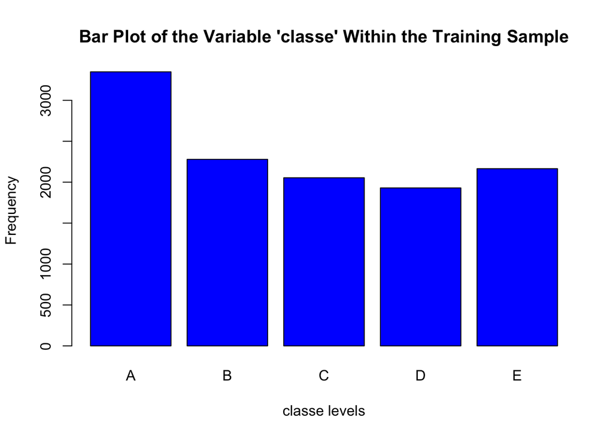

## Prediction

### Model One: Decision Trees

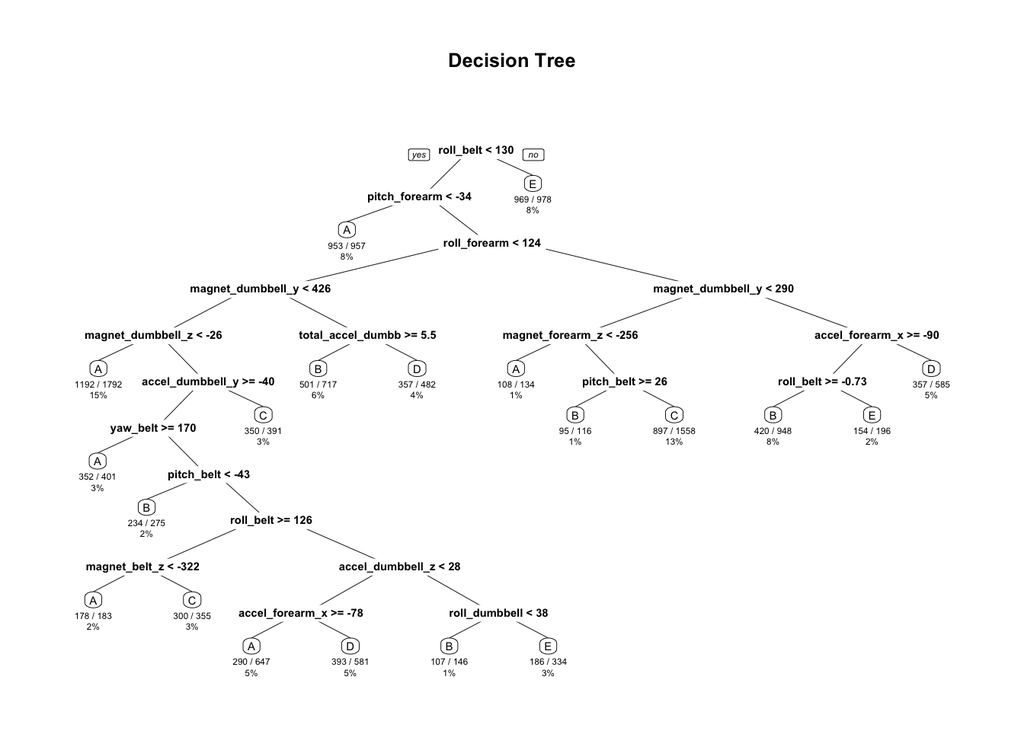

```r
model_one <- rpart(classe ~ ., data=training_sample, method="class")
rpart.plot(model_one, main="Decision Tree", extra=102, under=TRUE, faclen=0)
```

```r
# Prediction
prediction_one <- predict(model_one, testing_sample, type = "class")

# Testing Prediction Results
confusionMatrix(prediction_one, testing_sample$classe)
```

```
## Confusion Matrix and Statistics
##
##           Reference
## Prediction    A    B    C    D    E
##          A 2019  316   95  226   75
##          B   91  955  155   73  250
##          C   63  102 1010  201  165
##          D   49  119  108  685   75
##          E   10   26    0  101  877
##
## Overall Statistics
##
##                Accuracy : 0.7069
##                  95% CI : (0.6966, 0.7169)
##     No Information Rate : 0.2845
##     P-Value [Acc > NIR] : < 2.2e-16
##
##                   Kappa : 0.626
##  Mcnemar's Test P-Value : < 2.2e-16
##
## Statistics by Class:
##
##                      Class: A Class: B Class: C Class: D Class: E
## Sensitivity            0.9046   0.6291   0.7383  0.53266   0.6082
## Specificity            0.8732   0.9101   0.9180  0.94649   0.9786
## Pos Pred Value         0.7393   0.6266   0.6554  0.66120   0.8649
## Neg Pred Value         0.9584   0.9109   0.9432  0.91175   0.9173
## Prevalence             0.2845   0.1935   0.1744  0.16391   0.1838
## Detection Rate         0.2573   0.1217   0.1287  0.08731   0.1118
## Detection Prevalence   0.3481   0.1942   0.1964  0.13204   0.1292
## Balanced Accuracy      0.8889   0.7696   0.8282  0.73958   0.7934
```

### Model Two: Random Forests

```r
model_two <- randomForest(classe ~. , data=training_sample, method="class")

# Prediction:
prediction_two <- predict(model_two, testing_sample, type = "class")

# Test Prediction Results:
confusionMatrix(prediction_two, testing_sample$classe)
```

```
## Confusion Matrix and Statistics
##
##           Reference
## Prediction    A    B    C    D    E
##          A 2231    8    0    0    0
##          B    1 1510    9    0    0
##          C    0    0 1359   17    0
##          D    0    0    0 1269    1
##          E    0    0    0    0 1441
##
## Overall Statistics
##
##                Accuracy : 0.9954
##                  95% CI : (0.9937, 0.9968)
##     No Information Rate : 0.2845
##     P-Value [Acc > NIR] : < 2.2e-16
##
##                   Kappa : 0.9942
##  Mcnemar's Test P-Value : NA
##
## Statistics by Class:
##
##                      Class: A Class: B Class: C Class: D Class: E
## Sensitivity            0.9996   0.9947   0.9934   0.9868   0.9993
## Specificity            0.9986   0.9984   0.9974   0.9998   1.0000
## Pos Pred Value         0.9964   0.9934   0.9876   0.9992   1.0000
## Neg Pred Value         0.9998   0.9987   0.9986   0.9974   0.9998
## Prevalence             0.2845   0.1935   0.1744   0.1639   0.1838
## Detection Rate         0.2843   0.1925   0.1732   0.1617   0.1837
## Detection Prevalence   0.2854   0.1937   0.1754   0.1619   0.1837
## Balanced Accuracy      0.9991   0.9966   0.9954   0.9933   0.9997
```

## Results

As expected, the random forest model yielded better results than the decision tree model, with an out of sample error of .0046 vs .2931 respectively. Thus the random forest model will be used for the assignment submission.